# CHAPTER 8: SIMULATIONS IN R

8.1 Mathematics Function In Chapter 1, it was shown that R can function like a calculator. It is also able to be used to solve complex mathematical problems including calculus and linear algebra. Some of built-in mathematics functions are as follows.

Example 8.1a Minimun and Maximum

```r
## Min, Max, pmin, pmax
v1 <- c(5,3,11,7,6,8)
m1 <- matrix(v1, nrow=3, ncol=2)
m1
```

```
     [,1] [,2]
[1,]    5    7
[2,]    3    6
[3,]   11    8
```

```r
min(m1[,1],m1[,2])
```

```
[1] 3
```

```r
min(m1[,1])
```

```
[1] 3
```

```r
min(m1[,2])
```

```
[1] 6
```

```r
pmin(m1[,1],m1[,2])
```

```
[1] 5 3 8
```

```r
max(m1[,1],m1[,2])
```

```
[1] 11
```

```r
pmax(m1[,1],m1[,2])
```

```
[1]  7  6 11
```

```r
colMeans(m1)
```

```
[1] 6.333333 7.000000
```

```r
rowMeans(m1)
```

```
[1] 6.0 4.5 9.5
```

```r
sqrt(var(m1[,1]))
```

```
[1] 4.163332
```

```r
sqrt(var(m1[,2]))
```

```
[1] 1
```

Example 8.1b Cumulative Sum and Product

```r
## Cumulative Sum and Product
x <- seq(2, 8, by = 2)
x
```

```
[1] 2 4 6 8
```

```r
sum(x)
```

```
[1] 20
```

```r
cumsum(x)
```

```
[1]  2  6 12 20
```

```r
prod(x)
```

```
[1] 384
```

```r
cumprod(x)
```

```
[1]   2   8  48 384
```

```r
#own codes
zm <- seq(-9, 18, by = 3)
zm
```

```
 [1] -9 -6 -3  0  3  6  9 12 15 18
```

```r
sum(zm)
```

```
[1] 45
```

```r
cumsum(zm)
```

```
 [1]  -9 -15 -18 -18 -15  -9   0  12  27  45
```

```r
prod(zm)
```

```
[1] 0
```

```r
cumprod(zm)
```

```
 [1]   -9   54 -162    0    0    0    0    0    0    0
```

Example 8.1c Minimization/ Maximization Function

```r
# Function to Minimize/ Maximize: nlm(.)
# Apply Newton-Raphson method
# nlm(function(input) return(equation), initial input)
x <- 1:1000
head(x);tail(x)
```

```
[1] 1 2 3 4 5 6
[1]  995  996  997  998  999 1000
```

```r
nlm(function(x) return(x^2 -2* sin(x)),10)
```

```
$minimum
[1] -0.8009772

$estimate
[1] 0.7390846

$gradient
[1] -6.661338e-10

$code
[1] 1

$iterations
[1] 6
```

```r
y <- x^2 - 2*sin(x)
head(y);tail(y)
```

```
[1] -0.682942  2.181405  8.717760 17.513605 26.917849 36.558831
[1] 990023.5 992016.2 994010.8 996005.7 998001.1 999998.3
```

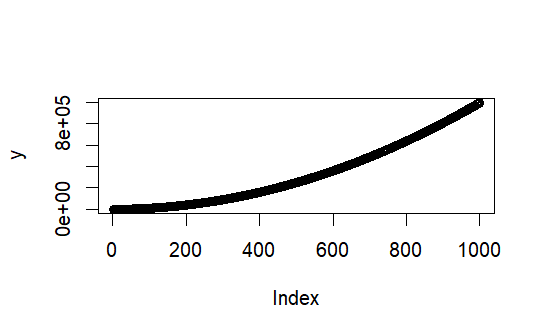

```r
plot(y)
```

```r
x2 <- seq(-10,10,by=0.2)
head(x2); tail(x2)
```

```
[1] -10.0  -9.8  -9.6  -9.4  -9.2  -9.0
[1]  9.0  9.2  9.4  9.6  9.8 10.0
```

```r
nlm(function(x2) return(x2^2 -2* sin(x2)),10)
```

```
$minimum
[1] -0.8009772

$estimate
[1] 0.7390846

$gradient
[1] -6.661338e-10

$code
[1] 1

$iterations
[1] 6
```

```r
y <- x2-2 +2* sin(x2)
head(y); tail(y)
```

```
[1] -10.91196 -11.06704 -11.25135 -11.44955 -11.64578 -11.82424
[1] 7.824237 7.645780 7.449551 7.251346 7.067042 6.911958
```

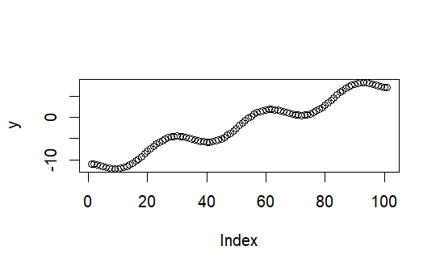

```r
plot(y)
```

Example 8.1d Calculus

Differentiation: D(expression(function)),“variable”)

Definite Integration: integrate(function(argument) equation, lower limit, upper limit)

```r
## Calculus
## Differentiation
D(expression(x + 2*x^3),"x")
```

```
1 + 2 * (3 * x^2)
```

```r
## Integration
integrate( function(x) sqrt(x) , 0,1)
```

```
0.6666667 with absolute error < 7.7e-05
```

8.2 Function for Statistical Distribution R provides function for most of the statistical distributions. The probability distribution functions are prefixed as follows. • d : density or probability density function (pdf) • p : cumulative density function (cdf) • q : quantile function or inverse of cdf • r : random number generation

Normal Distribution

Example 8.2a Probability Density Function: dnorm()

```r
## dnorm, Syntax: dnorm(x, mean, sd)
x <- seq(-10, 10, by = .01)
y <- dnorm(x, mean = 5.5, sd = 0.5)
head(x);tail(x)
```

```
[1] -10.00  -9.99  -9.98  -9.97  -9.96  -9.95
[1]  9.95  9.96  9.97  9.98  9.99 10.00
```

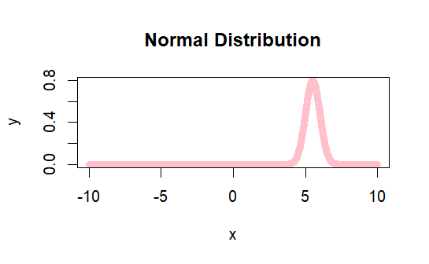

```r
plot(x,y, main = "Normal Distribution", col = "pink")
```

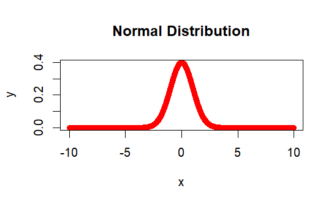

```r
x <- seq(-10, 10, by = .01)
y <- dnorm(x, mean = 0, sd = 1)
plot(x,y, main = "Normal Distribution", col = "red")
```

Example 8.2b Cumulative Density Function: pnorm()

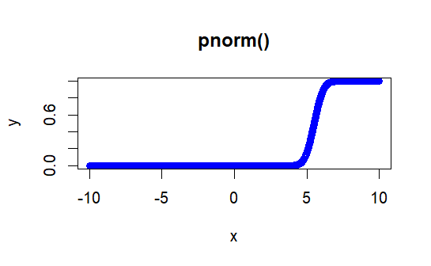

```r
#pnorm()
#Syntax: pnorm(x,mean,sd)
x <- seq(-10, 10, by = .01)
y <- pnorm(x, mean = 5.5, sd = 0.5)
plot(x,y, main = "pnorm()", col = "blue")
```

Example 8.2c Quantile Function: qnorm()

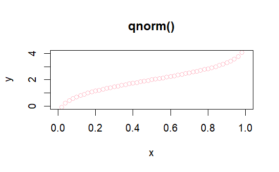

```r
#qnorm()
#Syntax: qnorm(x,mean,sd)
x <- seq(0, 1, by = 0.02)
y <- qnorm(x, mean = 2, sd = 1)
plot(x,y, main = "qnorm()", col = "pink")
```

```r
###Note that, input value for this function must be between 0 and 1.
```

Example 8.2d Randon data: rnorm()

```r
set.seed(7035)
x_nonstandard <- rnorm(50,12,3) #n=50, mean=12, sd=3
x_nonstandard
```

```
 [1] 10.888363 10.457497 13.682604  9.199017 10.268240 14.486224 15.536594 11.633678  8.183530 13.680958 13.941460
[12] 14.732084  8.862503 12.542957 14.068189 11.742156 11.094456 13.406459 11.294431  5.112099 13.168435  7.871751
[23] 11.584460  9.688007 14.742184 14.252233  8.864236  8.209233 11.077732 11.414491 13.168174 13.334873 13.175925
[34] 11.113439  5.114107  7.924445 12.321354  7.500441 16.666630 13.360852 12.198566 15.760184 13.614778  9.693474
[45] 11.297678 13.405860  4.055652 14.216655 14.867002 13.536828
```

```r
describe(x_nonstandard)
```

|  | vars | n | mean | sd | median | trimmed | mad | min | max | range | skew | kurtosis | se |
| --- | --- | --- | --- | --- | --- | --- | --- | --- | --- | --- | --- | --- | --- |
| X1 | 1 | 50 | 11.64 | 2.86 | 11.97 | 11.87 | 2.54 | 4.06 | 16.67 | 12.61 | -0.71 | -0.06 | 0.41 |

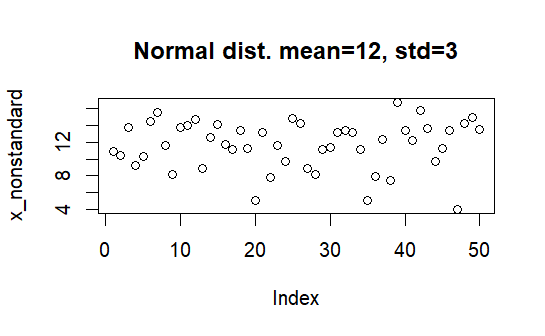

```r
plot(x_nonstandard, main="Normal dist. mean=12, std=3")
```

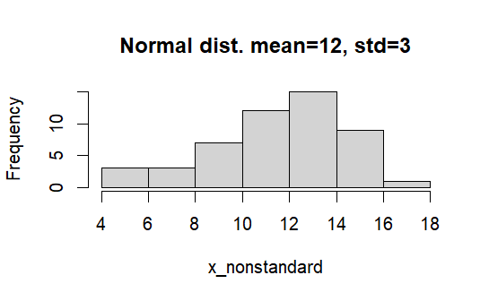

```r
hist(x_nonstandard, main="Normal dist. mean=12, std=3")
```

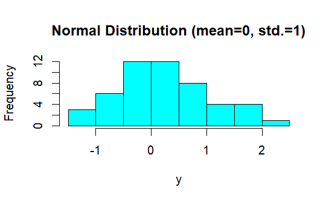

```r
#rnorm()
#Syntax: rnorm(n, mean, sd)
y <- rnorm(50) #standard normal
hist(y, main = "Normal Distribution (mean=0, std.=1)",
col = "cyan")
```

Poisson Distribution

Example 8.2e Probability Density Function: dpois()

```r
## dpois, Syntax: dpois(x, lambda)
set.seed(57)
x <- seq(0, 50, by = 1); head(x); tail(x)
```

```
[1] 0 1 2 3 4 5
[1] 45 46 47 48 49 50
```

```r
y <- dpois(x, lambda=3); head(x); tail(x)
```

```
[1] 0 1 2 3 4 5
[1] 45 46 47 48 49 50
```

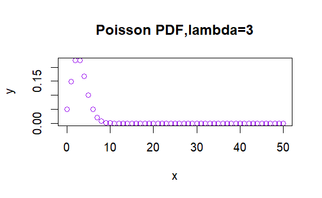

```r
plot(x,y, main = "Poisson PDF,lambda=3", col = "purple")
```

Example 8.2f Cumulative Density Function: ppois()

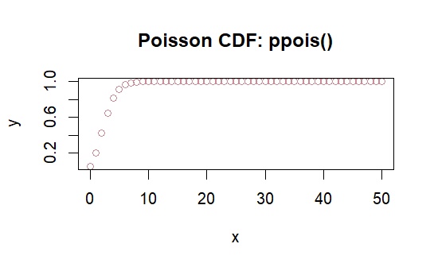

```r
#ppois()
#Syntax: ppois(x,lambda)
set.seed(57)
x <- seq(0, 50, by = 1)
y <- ppois(x, lambda=3)
plot(x,y, main = "Poisson CDF: ppois()", col = "lightpink3")
```

Example 8.2g Quantile Function: qpois()

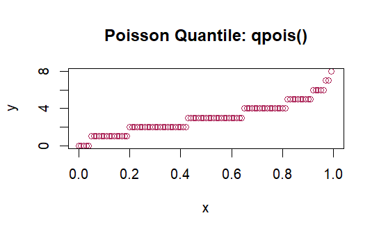

```r
#qpois()
#Syntax: qpois(x,lambda)
set.seed(57)
x <- seq(0, 1, by = 0.01)
y <- qpois(x, lambda=3)
plot(x,y, main = "Poisson Quantile: qpois()", col = "maroon")
```

```r
###Note that, input value for this function must be between 0 and 1.
```

Example 8.2h Random data: rpois()

```r
# random number: rpois(x,lambda)
set.seed(57)
dt_pois <- rpois(50,5)
head(dt_pois); tail(dt_pois)
```

```
[1] 3 5 1 3 6 6
[1] 4 2 2 5 5 4
```

```r
library(psych)
describe(dt_pois)
```

|  | vars | n | mean | sd | median | trimmed | mad | min | max | range | skew | kurtosis | se |
| --- | --- | --- | --- | --- | --- | --- | --- | --- | --- | --- | --- | --- | --- |
| X1 | 1 | 50 | 5.06 | 2.72 | 5 | 4.9 | 2.97 | 0 | 11 | 11 | 0.44 | -0.67 | 0.38 |

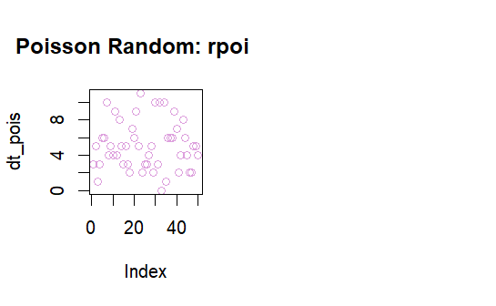

```r
par(mfrow=c(1,2))
plot(dt_pois, main = "Poisson Random: rpois()", col= "plum")
hist(dt_pois, main = "Histogram: Poisson Random: rpois()", col= "violet")
```

[output not shown]

8.3 Simulation Programming in R

Example 8.3a Generate Random Numbers

For normal distribution, the random numbers can be generated as follows:

• Generate random number of Standard normal

```r
## Generate random number of standard normal
x_standard <- rnorm(50) #n=50, mean=>0, sd=<1
x_standard
```

```
 [1] -0.35483891  0.02562148  0.14767711  2.28723226  1.04981464  0.10002431 -0.67291347 -0.69238721  0.88381796
[10] -0.61219188  1.04105317  0.19100247  1.69712224 -1.61819118 -2.73631457 -0.11344296 -0.80012999  0.76159386
[19] -1.85107221 -0.29448084 -0.18350261  0.15343118  0.44787228  1.86349265  0.51064814  1.00560439  0.17718666
[28] -0.02798027  1.43247575  1.65238143 -0.02655117  0.64163980  0.97881353 -0.07295137  0.54790747  0.90315568
[37] -1.14044397  1.13000898 -1.30290200 -0.11120364 -0.59153463  1.12623833 -0.97529261 -0.43994859  1.42834975
[46]  0.66144748 -1.11582305 -0.95021486  0.09910394  1.64664843
```

```r
## Descriptive summary
library(psych)
describe(x_standard)
```

|  | vars | n | mean | sd | median | trimmed | mad | min | max | range | skew | kurtosis | se |
| --- | --- | --- | --- | --- | --- | --- | --- | --- | --- | --- | --- | --- | --- |
| X1 | 1 | 50 | 0.16 | 1.04 | 0.12 | 0.19 | 1.14 | -2.74 | 2.29 | 5.02 | -0.3 | -0.13 | 0.15 |

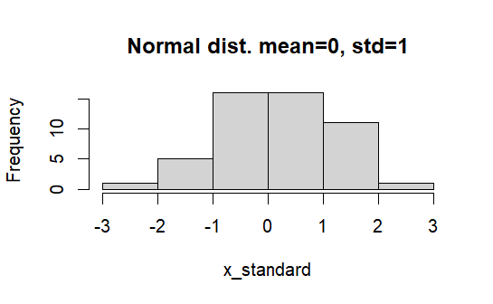

```r
hist(x_standard, main="Normal dist. mean=0, std=1")
```

• Generate random number of non-standard normal

```r
x_nonstandard <- rnorm(50,12,3) #n=50, mean=12, sd=3
x_nonstandard
```

```
 [1] 10.427437 10.364034 12.409364 13.057780 10.984957  9.294129 14.751117 12.661977  7.309553 12.758913  9.112873
[12] 15.196549 19.026177 17.819888 13.016436  9.473680  6.680816  9.319507 12.810846  8.592930 11.913836 10.249085
[23] 12.273392  9.146103 11.899910 11.811318 12.093306 11.716613 14.719245 14.563795 11.952200  9.655423 13.124525
[34]  7.472630 12.845069  9.282755 10.749683 11.825055 12.841973  8.888922 13.558216 10.745235 11.887039 16.320968
[45] 17.394318 11.371211  6.708210 10.723713 12.921643 15.135991
```

```r
describe(x_nonstandard)
```

|  | vars | n | mean | sd | median | trimmed | mad | min | max | range | skew | kurtosis | se |
| --- | --- | --- | --- | --- | --- | --- | --- | --- | --- | --- | --- | --- | --- |
| X1 | 1 | 50 | 11.82 | 2.73 | 11.89 | 11.71 | 2.22 | 6.68 | 19.03 | 12.35 | 0.39 | 0.04 | 0.39 |

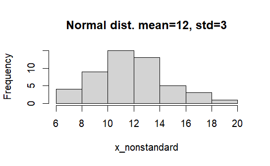

```r
hist(x_nonstandard, main="Normal dist. mean=12, std=3")
```

Descriptive Summary and Histogram - Standard Normal

Descriptive Summary and Histogram - Non-Standard Normal

Seed of Random Numbers

Example 8.3b set.seed()

```r
## seed of random number
set.seed(1234) #to reproduce the same group of values
x_standard <- rnorm(50) ; x_standard
```

```
 [1] -1.20706575  0.27742924  1.08444118 -2.34569770  0.42912469  0.50605589 -0.57473996 -0.54663186 -0.56445200
[10] -0.89003783 -0.47719270 -0.99838644 -0.77625389  0.06445882  0.95949406 -0.11028549 -0.51100951 -0.91119542
[19] -0.83717168  2.41583518  0.13408822 -0.49068590 -0.44054787  0.45958944 -0.69372025 -1.44820491  0.57475572
[28] -1.02365572 -0.01513830 -0.93594860  1.10229755 -0.47559308 -0.70944004 -0.50125806 -1.62909347 -1.16761926
[37] -2.18003965 -1.34099319 -0.29429386 -0.46589754  1.44949627 -1.06864272 -0.85536463 -0.28062300 -0.99434008
[46] -0.96851432 -1.10731819 -1.25198589 -0.52382812 -0.49684996
```

```r
describe(x_standard)
```

|  | vars | n | mean | sd | median | trimmed | mad | min | max | range | skew | kurtosis | se |
| --- | --- | --- | --- | --- | --- | --- | --- | --- | --- | --- | --- | --- | --- |
| X1 | 1 | 50 | -0.45 | 0.89 | -0.54 | -0.52 | 0.68 | -2.35 | 2.42 | 4.76 | 0.77 | 1.15 | 0.13 |

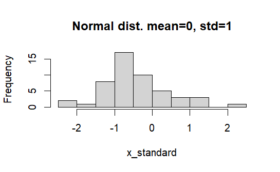

```r
hist(x_standard, main="Normal dist. mean=0, std=1")
```

Example 8.3c set.seed()

```r
set.seed(7035)
x_nonstandard <- rnorm(50,12,3); x_nonstandard
```

```
 [1] 10.888363 10.457497 13.682604  9.199017 10.268240 14.486224 15.536594 11.633678  8.183530 13.680958 13.941460
[12] 14.732084  8.862503 12.542957 14.068189 11.742156 11.094456 13.406459 11.294431  5.112099 13.168435  7.871751
[23] 11.584460  9.688007 14.742184 14.252233  8.864236  8.209233 11.077732 11.414491 13.168174 13.334873 13.175925
[34] 11.113439  5.114107  7.924445 12.321354  7.500441 16.666630 13.360852 12.198566 15.760184 13.614778  9.693474
[45] 11.297678 13.405860  4.055652 14.216655 14.867002 13.536828
```

```r
describe(x_nonstandard)
```

|  | vars | n | mean | sd | median | trimmed | mad | min | max | range | skew | kurtosis | se |
| --- | --- | --- | --- | --- | --- | --- | --- | --- | --- | --- | --- | --- | --- |
| X1 | 1 | 50 | 11.64 | 2.86 | 11.97 | 11.87 | 2.54 | 4.06 | 16.67 | 12.61 | -0.71 | -0.06 | 0.41 |

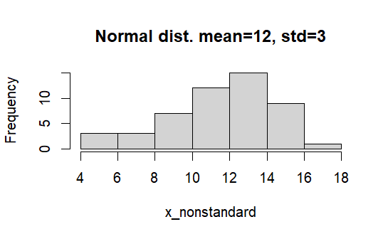

```r
hist(x_nonstandard, main="Normal dist. mean=12, std=3")
```

Normality Test

```r
dt <- read.csv("C:\\Users\\user\\OneDrive\\Desktop\\Sem4 slide\\data science programming 2\\dt_clean.csv", header=TRUE)
dt
```

| Section | ID_no | Gender | weight | height | bmi | categories |
| --- | --- | --- | --- | --- | --- | --- |
| Section 02G | 1001 |  | 50.0 | 1.70 | 17.30104 | Underweight |
| Section 01G | 1002 | Female | 72.0 | 1.66 | 26.12861 | Overweight |
| Section 02G | 1003 | Female | 55.0 | 1.60 | 21.48438 | Normal |
| Section 01G | 1004 | Female | 53.9 | 1.56 | 22.14826 | Normal |
| Section 01G | 1005 | Female | 72.0 | 1.60 | 28.12500 | Overweight |
| Section 01G | 1006 | Female | 78.0 | 1.56 | 32.05128 | Obese |
| Section 02G | 1007 | Male | 71.0 | 1.79 | 22.15911 | Normal |
| Section 01G | 1008 | Female | 46.0 | 1.61 | 17.74623 | Underweight |
| Section 01G | 1009 | Male | 55.0 | 1.84 | 16.24527 | Underweight |
| Section 01G | 1010 | Female | 57.0 | 1.65 | 20.93664 | Normal |

[output cut: 61 more lines]

```r
dt$weight <- as.numeric(dt$weight)
```

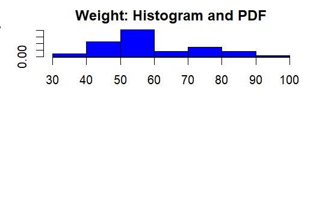

```r
## Observed data
par(mfrow=c(2,1))
par(mar = c(3, 3, 2, 2))
hist(dt$weight, col="blue", border="black",
     prob = TRUE,xlab = "weight",
     main = "Weight: Histogram and PDF")
```

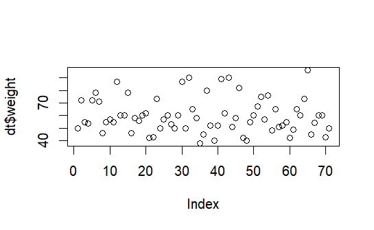

```r
plot(dt$weight)
lines(density(dt$weight),lwd = 2,col = "red")
```

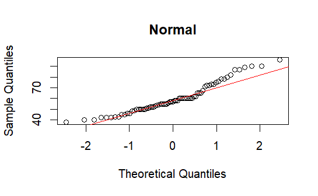

```r
qqnorm(dt$weight, main='Normal')
qqline(dt$weight, col="red")
```

R code: Shapiro-Wilk and Kolmogorov-Smirnov Tests

```r
## Shapiro-Wilk
shapiro.test(dt$weight)
```

```
    Shapiro-Wilk normality test

data:  dt$weight
W = 0.93698, p-value = 0.001464
```

```r
## Kolmogorov-Smirnov
ks.test(dt$weight, 'pnorm')
```

```
    Asymptotic one-sample Kolmogorov-Smirnov test

data:  dt$weight
D = 1, p-value < 2.2e-16
alternative hypothesis: two-sided
```